2018-02-24

## 自己紹介

森林の研究をしています。

- Twitter: @monotropastrum
- researchmap: https://researchmap.jp/read0208767/
- GitHub: https://github.com/ito4303
  - この発表資料のファイル一式 https://github.com/ito4303/SappoRoR8

## かかわっているプロジェクト

- ``Bayesian Population Analysis using WinBUGS''のStan移植
  - https://github.com/stan-dev/example-models/tree/master/BPA
  - 原本の日本語訳: 『BUGSで学ぶ階層モデリング入門—個体群のベイズ解析』（飯島勇人・伊東宏樹・深谷肇一・正木隆 訳, 共立出版）
- Stanマニュアルの日本語への翻訳プロジェクト
  - https://github.com/stan-ja/stan-ja

## ありがとうぞうさん

SappoRo.R #6: R Markdownによるスライド生成（前田さん）

http://kazutan.github.io/SappoRoR6/rmd_slide.html

## その後

- revealjsをためてしてみた。
- なかなかよかった。
- 次はR Markdown + Beamerでやってみよう。

## R Markdown + Beamer

RStudioで，R Markdownを新規に作成するときに， Beamerでプレゼンテーションファイルを作成するオプションあり。

## なぜR Markdown + Beamer

RStudioだけで，数式も，Rコードも，  
グラフもすべて完結。

## 用意したもの

- RStudio
- TeXLive 2017 (MacTeX 2017)

## 使用方法

ふつうにR Markdown

## yamlヘッダの設定

title中の改行は‘|’をいれる。 (https://stackoverflow.com/questions/28895109/how-can-i-force-a-line-break-in-rmarkdowns-title)

## 欧文フォントの設定

`in_header`で指定したファイルで設定。

fontencパッケージを使用するようにした。

luatex使用の場合，デフォルトのbeamerテンプレートでfontspecパッケージが 呼ばれるが，そうするとupquoteパッケージが有効にならず，コードチャンク中の 二重引用符が「`"`」ではなく「`”`」になってしまうようだ。

## 日本語フォントの設定

日本語フォントの設定は欧文フォントとは別になっている。

## luatexjaの設定

luatexjaの公式ドキュメントがくわしい（当然）。

- コマンドラインから`texdoc luatexja`

または

- http://mirrors.ctan.org/macros/luatex/generic/luatexja/doc/luatexja-ja.pdf

## fragile関係のエラー

**解決法:** タイトルのあとに`{.fragile}`をつける。

## 数式

LaTeXなので，数式は問題なし。RStudioではプレビューも表示される。

\[ \Pr(x \mid \mu, \sigma) = \frac{1}{\sqrt{2\pi}\sigma} \exp\left(-\frac{(x - \mu)^2}{2\sigma^2}\right) \]

## Rでグラフ

Rなので，グラフも。

しかし，デフォルトでは はみでる。

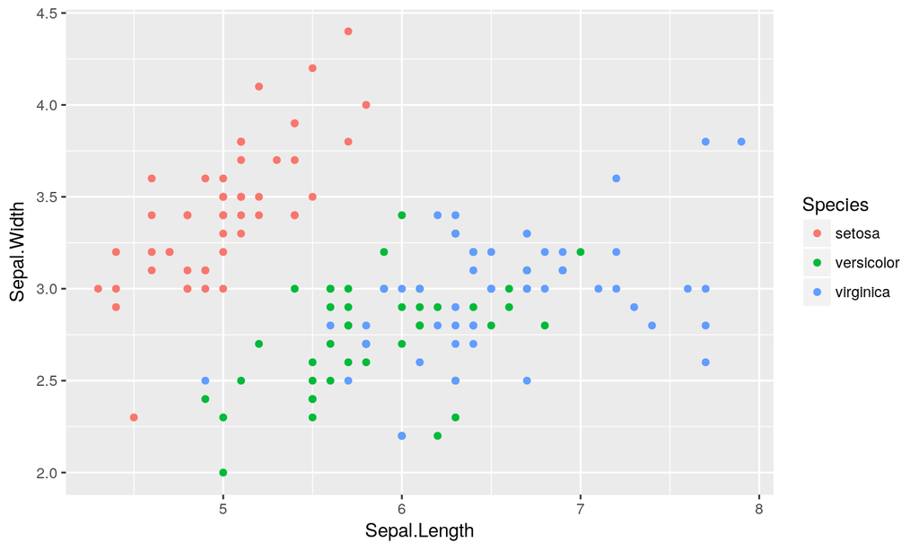

```r
p <- ggplot(iris, aes(Sepal.Length, Sepal.Width,
                      colour = Species)) +
  geom_point()
print(p)
```

## チャンクでのオプション指定

ドキュメントをみる。

- knitr > Chunk options and package options (Yihui Xieさん)
  - https://yihui.name/knitr/options/#plots

## サイズ調整

チャンクオプションで`fig.width=4,fig.height=2.5`と`out.height="5cm"`を指定した。

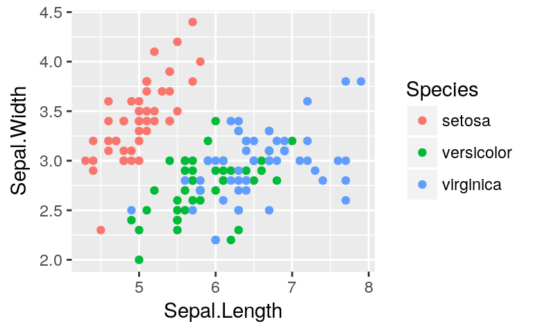

```r
print(p)
```

## グラフの日本語フォント

チャンクオプションで， `dev="cairo_pdf"`を指定すると，日本語フォントの 表示ができる。

```r
spc <- c("ヒオウギアヤメ", "イリス・ウェルシコロル",
         "イリス・ヴァージニカ")
p + labs(x = "萼の長さ(cm)", y = "萼の幅(cm)") +
         scale_colour_discrete(name = "種", labels = spc)
```

[figure not shown]

## まとめ

- CSSの知識があれば，revealjsの方が楽かも。
- でも，なんとかなる。
- ドキュメントをよむ。
- 先人の知恵を活用する。
- いったん設定ができてしまえば，あとは楽?